# STAT/MATH 495: Problem Set 09

Anthony Rentsch

2017-11-07

# Question 1: Run k-means

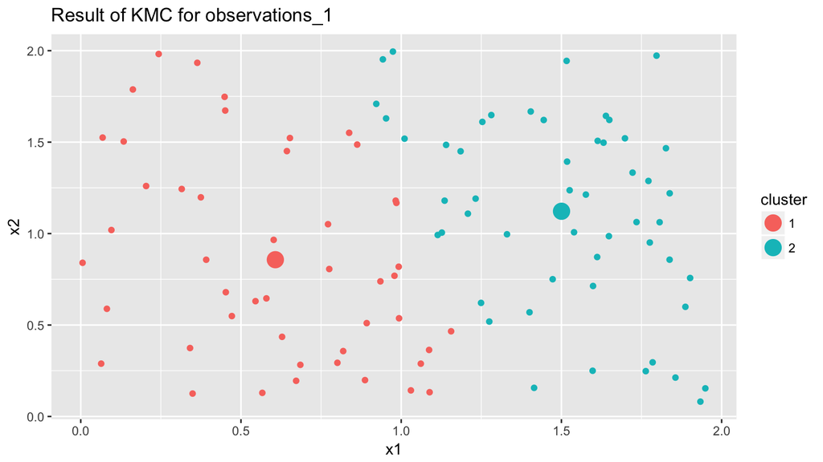

[figure not shown]

[figure not shown]

```r
observations_1 <- read_csv("data/observations_1.csv")
observations_2 <- read_csv("data/observations_2.csv")

# Set observations to be one of two datasets
observations <- observations_1

# Fit model for k=2
k <- 2
k_means_results <- kmeans(observations, centers=k)
clusters <- k_means_results$cluster
cluster_centers <- k_means_results$centers

# Add cluster results to observations. Note we convert to factor since cluster
# ID's should be treated as categorical
observations$cluster <- as.factor(clusters)

# Add cluster ID's to cluster_centers
cluster_centers <- cluster_centers %>%
  as_tibble() %>%
  mutate(cluster=as.factor(1:k))

ggplot(NULL, aes(x=x1, y=x2, col=cluster)) +
  geom_point(data=observations) +
  geom_point(data=cluster_centers, size=5) +
  labs(title = "Result of KMC for observations_1")
```

**Questions**:

1. Run KMC 10 times on `observations_1` and comment on the consistency of the results.
2. Speculate on the root cause of any consistency or inconsistency in the results.
3. Run KMC 10 times on `observations_2` and comment on the consistentcy of the results.
4. Speculate on the root cause of any consistency or inconsistency in the results.

**Answers**:

1. The results of running the KMC on `observations_1` were very inconsistent. For instance, in three separate runs the left-most cluster was centered at, roughly, (0.6, 0.8) then (0.95, 0.5) and then (0.7, 0.7). Since the centers changed dramatically from instance to instance, individual data points got grouped differently nearly every time.
2. Unlike `observations_2`, the `observations_1` data is not “pre-clustered,” if you will. Looking at the scatterplot above, there is no discernible pattern in the data and much less of a discernible clustering pattern. Since there is no natrual pattern in the data for the KMC algorithm to fit, it fits to noise each time, which produces unpredictable and inconsistent results. Furthermore, the clusters that I observe are likely a result of the initial positions of the centers. Since the points are fairly uniformly dispersed over the domain, it is reasonable to suspect that a different pair of initial centers would lead the algorithm to find substantially different final clusters.
3. The results were extremely consistent. In every run, the clusters emerged in the group of points centered at the bottom left (low x1 and x2 values) and in the group of points centered at the top right (high x1 and x2 values). The clusters even ended up in roughly the same position from instance to instance (around (0.5, 0.5) and (1.5, 1.5)). Even the two points that are close to being equidistant from either cluster (roughly x1 = x2 = 1) ended up in the cluster that they were slightly closer to each time.
4. I suspect that the clustering algorithm produced nearly identical results each time because the observations that the model was trained on were “pre-clustered.” In other words, `observations_2` were already roughly grouped into two distinct clouds of points, which allowed for the KMC (k=2) algorithm to cluster the points in a way that was already natural to the data. This can be seen in the scatterplot above. Here, the selection of initial points is unimportant for the algorithm’s outcome because the data is positioned in such a way that clusters will form in the locations from instance to instance.

# Bonus question: Code your own

Read ISLR page 388 Algorithm 10.1 and implement k-means clustering from scratch. Don’t worry about doing it for general $k$; keep it simple and do it for $k=2$ specifically. Apply it to `observations_2` from above.

```r
# Initialize (random) cluster assignments
clusters <- data.frame(x1 = observations_2$x1,
                       x2 = observations_2$x2,
                       old_cluster = sample(c(1,2), 100, replace = T))

# Initialize centers
centers <- data_frame(
  x1 = c(1, 0),
  x2 = c(1, 0)
)

# Do initial computations for
# distance between each point and center
distance_matrix <- proxy::dist(x = data.frame(clusters$x1, clusters$x2), y = centers)

# which cluster each point is assigned to
clusters <- cbind(clusters, new_cluster = apply(distance_matrix, 1, which.min))

# how many point were assigned to a new cluster
changes <- nrow(clusters[clusters$old_cluster != clusters$new_cluster,])

while(changes != 0){
  # recompute centers
  centers <- data_frame(
  x1 = c(mean(clusters$x1[clusters$new_cluster == 1]), mean(clusters$x1[clusters$new_cluster == 2])),
  x2 = c(mean(clusters$x1[clusters$new_cluster == 1]), mean(clusters$x2[clusters$new_cluster == 2]))
  )
  # reassign new_cluster values to old_cluster
  clusters$old_cluster <- clusters$new_cluster

  # compute distance between points and new centers
  distance_matrix <- proxy::dist(x = data.frame(clusters$x1, clusters$x2), y = centers)

  # calculate which center each point is now closer to
  clusters$new_cluster <- apply(distance_matrix, 1, which.min)

  # calculate how many points were assigned to a different cluster
  # once this = 0, the loop will terminate
  changes <- nrow(clusters[clusters$old_cluster != clusters$new_cluster,])
}
```

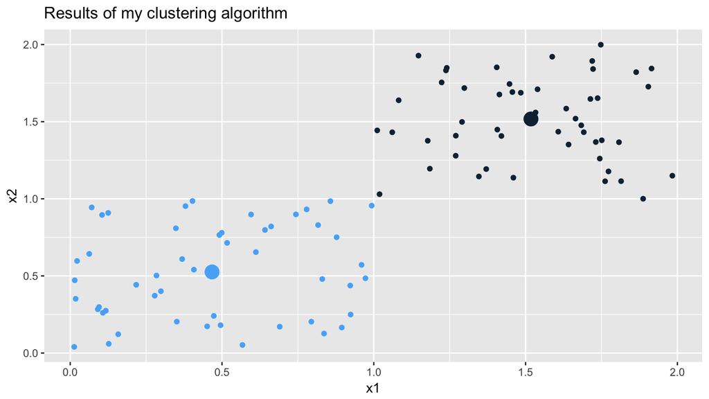